# EasyVisa Project

## EDA

- It is a good idea to explore the data once again after manipulating it.

### Company_size and case status

```
case_status   Certified  Denied    All
Company_Size
Small              4108    2133   6241
medium             3878    2037   5915
large              8559    4088  12647
Big                 473     204    677
All               17018    8462  25480
```

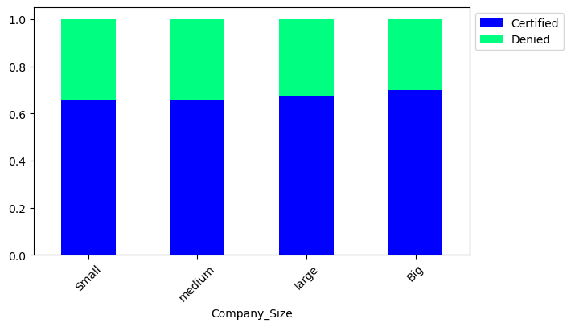

```python
stack_barplot(df, "Company_Size", "case_status")
```

**Observation**:

1. As similar to previous obervation size of company and employee has not much impact on approval or denial of visa application
2. There is slightly increase increase in probablity of approval for Big companies compared to others.

### Company_Age and case status

```
case_status  Certified  Denied    All
Company_Age
V_Old             4278    2178   6456
Old               4309    2226   6535
New               4451    2322   6773
Recent            3969    1731   5700
All              17007    8457  25464
```

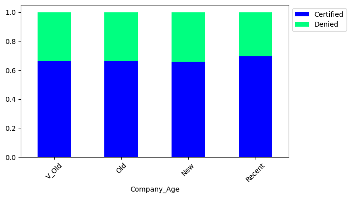

```python
stack_barplot(df, "Company_Age", "case_status")
```

**Observation**:

1. As similar to previous obervation age of company and employee has not much impact on visa application.
2. The recent companies slightly higher chance of visa approval than other companies.

**Case Status certified as 1 and cancelled as 0 to predict future cancellation**

```python
df["case_status"] = df["case_status"].apply(lambda x: 1 if x == "Certified" else 0)
```

```python
df.head()
```

|  | continent | education_of_employee | has_job_experience | requires_job_training | no_of_employees | yr_of_estab | region_of_employment | prevailing_wage | unit_of_wage | full_time_position | case_status | wages | Company_Size | Company_Age |
| --- | --- | --- | --- | --- | --- | --- | --- | --- | --- | --- | --- | --- | --- | --- |
| 0 | Asia | High School | N | N | 14513 | 2007 | West | 592.2029 | Hour | Y | 0 | Hourly | large | Recent |
| 1 | Asia | Master's | Y | N | 2412 | 2002 | Northeast | 83425.6500 | Year | Y | 1 | Annually | large | New |
| 2 | Asia | Bachelor's | N | Y | 44444 | 2008 | West | 122996.8600 | Year | Y | 0 | Annually | Big | Recent |
| 3 | Asia | Bachelor's | N | N | 98 | 1897 | West | 83434.0300 | Year | Y | 0 | Annually | Small | V_Old |
| 4 | Africa | Master's | Y | N | 1082 | 2005 | South | 149907.3900 | Year | Y | 1 | Annually | medium | New |

```python
#lets drop unit_of_wages, yr_of_estab, no_of_employee
visa_df = df.drop(['yr_of_estab','no_of_employees', 'unit_of_wage'], axis=1)
```

```python
visa_df.head()
```

|  | continent | education_of_employee | has_job_experience | requires_job_training | region_of_employment | prevailing_wage | full_time_position | case_status | wages | Company_Size | Company_Age |
| --- | --- | --- | --- | --- | --- | --- | --- | --- | --- | --- | --- |
| 0 | Asia | High School | N | N | West | 592.2029 | Y | 0 | Hourly | large | Recent |
| 1 | Asia | Master's | Y | N | Northeast | 83425.6500 | Y | 1 | Annually | large | New |
| 2 | Asia | Bachelor's | N | Y | West | 122996.8600 | Y | 0 | Annually | Big | Recent |
| 3 | Asia | Bachelor's | N | N | West | 83434.0300 | Y | 0 | Annually | Small | V_Old |
| 4 | Africa | Master's | Y | N | South | 149907.3900 | Y | 1 | Annually | medium | New |

## Data Preparation for modeling

- We want to predict which visa will be certified.
- Before we proceed to build a model, we'll have to encode categorical features.
- We'll split the data into train and test to be able to evaluate the model that we build on the train data.

### Creating training and test sets

```python
# specifying the independent  and dependent variables
X = visa_df.drop(["case_status"], axis=1)
Y = visa_df["case_status"]


# creating dummy variables
X = pd.get_dummies(X, drop_first=True)

# splitting data in train and test sets
X_train, X_test, y_train, y_test = train_test_split(X, Y, test_size=0.30, random_state=1,  stratify=Y)
```

```python
X.info()
```

```
<class 'pandas.core.frame.DataFrame'>
RangeIndex: 25480 entries, 0 to 25479
Data columns (total 23 columns):
 #   Column                             Non-Null Count  Dtype
---  ------                             --------------  -----
 0   prevailing_wage                    25480 non-null  float64
 1   continent_Asia                     25480 non-null  uint8
 2   continent_Europe                   25480 non-null  uint8
 3   continent_North America            25480 non-null  uint8
 4   continent_Oceania                  25480 non-null  uint8
 5   continent_South America            25480 non-null  uint8
 6   education_of_employee_Doctorate    25480 non-null  uint8
 7   education_of_employee_High School  25480 non-null  uint8
 8   education_of_employee_Master's     25480 non-null  uint8
 9   has_job_experience_Y               25480 non-null  uint8
 10  requires_job_training_Y            25480 non-null  uint8
 11  region_of_employment_Midwest       25480 non-null  uint8
 12  region_of_employment_Northeast     25480 non-null  uint8
 13  region_of_employment_South         25480 non-null  uint8
 14  region_of_employment_West          25480 non-null  uint8
 15  full_time_position_Y               25480 non-null  uint8
 16  wages_Hourly                       25480 non-null  uint8
 17  Company_Size_medium                25480 non-null  uint8
 18  Company_Size_large                 25480 non-null  uint8
 19  Company_Size_Big                   25480 non-null  uint8
 20  Company_Age_Old                    25480 non-null  uint8
 21  Company_Age_New                    25480 non-null  uint8
 22  Company_Age_Recent                 25480 non-null  uint8
dtypes: float64(1), uint8(22)
memory usage: 746.6 KB
```

```python
print("Shape of Training set : ", X_train.shape)
print("Shape of test set : ", X_test.shape)
print("Percentage of classes in training set:")
print(y_train.value_counts(normalize=True))
print("Percentage of classes in test set:")
print(y_test.value_counts(normalize=True))
```

```
Shape of Training set :  (17836, 23)
Shape of test set :  (7644, 23)
Percentage of classes in training set:
1    0.667919
0    0.332081
Name: case_status, dtype: float64
Percentage of classes in test set:
1    0.667844
0    0.332156
Name: case_status, dtype: float64
```

**Observation**;

1. The data (train and test) has split in ratio of 67 to 33 ratio for certified vs denied due to stratify.
2. All the data types of X is converted to numerical columns.

### EDA

To check correlation of newly created dummy variables

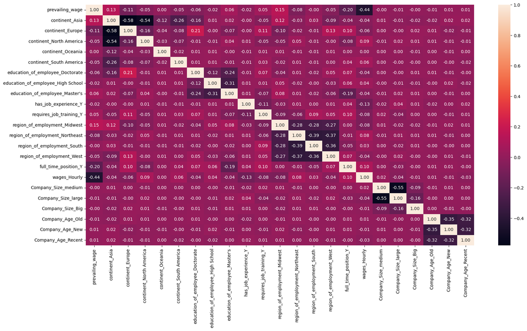

```python
plt.figure(figsize=(20,10))
sns.heatmap(X.corr(), annot=True, fmt='.2f')
```

**Observations**:

### Model can make wrong predictions as:

1. Model predicts that the visa application will get certified but in reality, the visa application should get denied.
2. Model predicts that the visa application will not get certified but in reality, the visa application should get certified.

### Which case is more important?

- Both the cases are important as:
- If a visa is certified when it had to be denied a wrong employee will get the job position while US citizens will miss the opportunity to work on that position.
- If a visa is denied when it had to be certified the U.S. will lose a suitable human resource that can contribute to the economy.

### How to reduce the losses?

- `F1 Score` can be used a the metric for evaluation of the model, greater the F1 score higher are the chances of minimizing False Negatives and False Positives.

```python
# defining a function to compute different metrics to check performance of a classification model built using sklearn


def model_performance_classification_sklearn(model, predictors, target):
    """
    Function to compute different metrics to check classification model performance

    model: classifier
    predictors: independent variables
    target: dependent variable
    """

    # predicting using the independent variables
    pred = model.predict(predictors)

    acc = accuracy_score(target, pred)  # to compute Accuracy
    recall = recall_score(target, pred)  # to compute Recall
    precision = precision_score(target, pred)  # to compute Precision
    f1 = f1_score(target, pred)  # to compute F1-score

    # creating a dataframe of metrics
    df_perf = pd.DataFrame(
        {"Accuracy": acc, "Recall": recall, "Precision": precision, "F1": f1,},
        index=[0],
    )

    return df_perf
```

```python
def confusion_matrix_sklearn(model, predictors, target):
    """
    To plot the confusion_matrix with percentages

    model: classifier
    predictors: independent variables
    target: dependent variable
    """
    y_pred = model.predict(predictors)
    cm = confusion_matrix(target, y_pred)
    labels = np.asarray(
        [
            ["{0:0.0f}".format(item) + "\n{0:.2%}".format(item / cm.flatten().sum())]
            for item in cm.flatten()
        ]
    ).reshape(2, 2)

    plt.figure(figsize=(4, 3))
    sns.heatmap(cm, annot=labels, fmt="")
    plt.ylabel("True label")
    plt.xlabel("Predicted label")
```

## Decision Tree - Model Building and Hyperparameter Tuning

```python
# building a decision tree using the dtclassifier function
dec_Tree = DecisionTreeClassifier(criterion = 'gini', random_state=1, class_weight='balanced')
dec_Tree.fit(X_train, y_train)
```

```
DecisionTreeClassifier(class_weight='balanced', random_state=1)
```

#### Checking model performance on training set

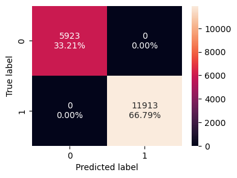

```python
confusion_matrix_sklearn(dec_Tree, X_train, y_train)
```

```python
decision_tree_perf_train = model_performance_classification_sklearn(
    dec_Tree, X_train, y_train
)
decision_tree_perf_train
```

|  | Accuracy | Recall | Precision | F1 |
| --- | --- | --- | --- | --- |
| 0 | 1.0 | 1.0 | 1.0 | 1.0 |

#### Checking model performance on test set

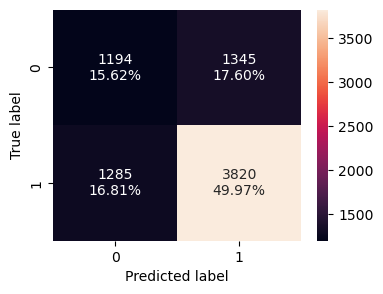

```python
confusion_matrix_sklearn(dec_Tree, X_test, y_test)
```

```python
decision_tree_perf_test = model_performance_classification_sklearn(
    dec_Tree, X_test, y_test
)
decision_tree_perf_test
```

|  | Accuracy | Recall | Precision | F1 |
| --- | --- | --- | --- | --- |
| 0 | 0.655939 | 0.748286 | 0.739593 | 0.743914 |

**Observation**:

1. The decision tree overfitting the training data with all values as 1 for accuracy, recall, precision and f1.
2. The accuracy is lowest .65 on test data
3. The recall, precision and f1 are around .74 for test data.

#### Will tuning the hyperparameters improve the model performance?

### Hyperparameter Tuning - Decision Tree

```python
# Choose the type of classifier.
dtree_estimator = DecisionTreeClassifier(random_state=1)

# Grid of parameters to choose from
parameters = {'max_depth': np.arange(5,30,5),
              'min_samples_leaf': [3, 5, 7],
              'max_leaf_nodes' : [2, 4, 6],
              'min_impurity_decrease': [0.0001,0.001,0.01,0.1]
             }

# Type of scoring used to compare parameter combinations
scorer = metrics.make_scorer(metrics.f1_score)

# Run the grid search
grid_obj = GridSearchCV(dtree_estimator, parameters, scoring=scorer, cv=5)
grid_obj = grid_obj.fit(X_train, y_train)

# Set the clf to the best combination of parameters
dtree_estimator = grid_obj.best_estimator_

# Fit the best algorithm to the data.
dtree_estimator.fit(X_train, y_train)
```

```
DecisionTreeClassifier(max_depth=5, max_leaf_nodes=4,
                       min_impurity_decrease=0.0001, min_samples_leaf=3,
                       random_state=1)
```

#### Checking model performance on training set

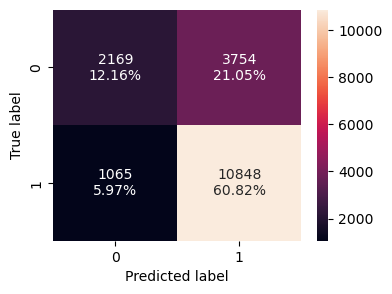

```python
confusion_matrix_sklearn(dtree_estimator, X_train, y_train)
```

```python
dtree_estimator_model_train= model_performance_classification_sklearn(dtree_estimator, X_train,y_train)
dtree_estimator_model_train
```

|  | Accuracy | Recall | Precision | F1 |
| --- | --- | --- | --- | --- |
| 0 | 0.729816 | 0.910602 | 0.742912 | 0.818254 |

#### Checking model performance on test set

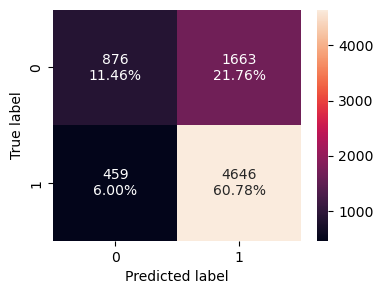

```python
confusion_matrix_sklearn(dtree_estimator, X_test, y_test)
```

```python
dtree_estimator_model_test = model_performance_classification_sklearn(
    dec_Tree, X_test, y_test
)
dtree_estimator_model_test
```

|  | Accuracy | Recall | Precision | F1 |
| --- | --- | --- | --- | --- |
| 0 | 0.655939 | 0.748286 | 0.739593 | 0.743914 |

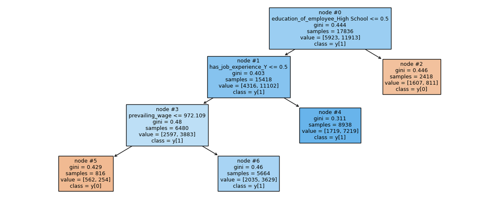

```python
#plotting the decision tree
plt.figure(figsize=(15,6))
tree.plot_tree(dtree_estimator,feature_names=feature_names,filled=True,fontsize=9,node_ids=True,class_names=True)
plt.show()
```

**Observation**:

## *Building bagging and boosting models*

## Bagging - Model Building and Hyperparameter Tuning

### Bagging Classifier

```python
#Train the Bagging classifier
bagging = BaggingClassifier(random_state=1)
bagging.fit(X_train,y_train)
```

```
BaggingClassifier(random_state=1)
```

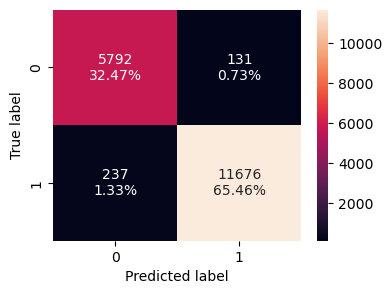

```python
confusion_matrix_sklearn(bagging, X_train, y_train)
```

```python
bagging_model_train = model_performance_classification_sklearn(bagging, X_train, y_train)
bagging_model_train
```

|  | Accuracy | Recall | Precision | F1 |
| --- | --- | --- | --- | --- |
| 0 | 0.979368 | 0.980106 | 0.988905 | 0.984486 |

#### Checking model performance on test set

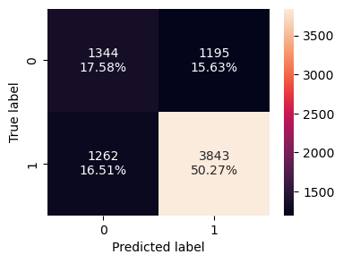

```python
confusion_matrix_sklearn(bagging, X_test, y_test)
```

```python
bagging_model_test= model_performance_classification_sklearn(bagging,
                                                             X_test, y_test)
bagging_model_test
```

|  | Accuracy | Recall | Precision | F1 |
| --- | --- | --- | --- | --- |
| 0 | 0.678571 | 0.752791 | 0.762803 | 0.757764 |

**Observation**:

1. The bagging is overfitting the training data with all values as .98 for accuracy, recall, precision and f1.
2. The accuracy is low at .67 for test data but slightly improved from previous models.
3. The recall is .75 precision and f1 are around .76 for test data, slightly improved from decision tree model.

#### Will tuning the hyperparameters improve this model performance?

### Hyperparameter Tuning - Bagging Classifier

```python
# Choose the type of classifier.
bagging_estimator_tuned = BaggingClassifier(random_state=1)

# Grid of parameters to choose from

parameters = {'max_samples': [0.7,0.8,0.9,1],
              'max_features': [0.7,0.8,0.9,1],
              "n_estimators": np.arange(90, 111, 10),

             }

# Type of scoring used to compare parameter combinations
acc_scorer = metrics.make_scorer(metrics.f1_score)

# Run the grid search
grid_obj = GridSearchCV(bagging_estimator_tuned, parameters, scoring=acc_scorer,cv=5)
grid_obj = grid_obj.fit(X_train, y_train)

# Set the clf to the best combination of parameters
bagging_estimator_tuned = grid_obj.best_estimator_

# Fit the best algorithm to the data.
bagging_estimator_tuned.fit(X_train, y_train)
```

```
BaggingClassifier(max_features=0.7, max_samples=0.7, n_estimators=110,
                  random_state=1)
```

#### Checking model performance on training set

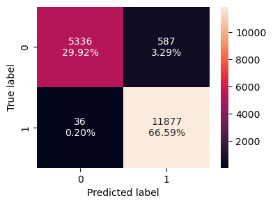

```python
confusion_matrix_sklearn(bagging_estimator_tuned, X_train, y_train)
```

```python
bagging_estimator_tuned_train = model_performance_classification_sklearn(bagging_estimator_tuned, X_train,y_train)
bagging_estimator_tuned_train
```

|  | Accuracy | Recall | Precision | F1 |
| --- | --- | --- | --- | --- |
| 0 | 0.965071 | 0.996978 | 0.952904 | 0.974443 |

#### Checking model performance on test set

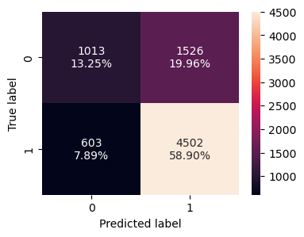

```python
confusion_matrix_sklearn(bagging_estimator_tuned, X_test, y_test)
```

```python
bagging_estimator_tuned_test= model_performance_classification_sklearn(bagging_estimator_tuned, X_test,y_test)
bagging_estimator_tuned_test
```

|  | Accuracy | Recall | Precision | F1 |
| --- | --- | --- | --- | --- |
| 0 | 0.721481 | 0.881881 | 0.746848 | 0.808767 |

Observation:

1. The bagging_estimator_tuned is still overfitting the training data with .96 for accuracy, .99 for recall, .95 for precision and .97 for f1.
2. The accuracy has quite improved to .72 for test data from previous models.
3. The recall is .88 precision is at.74 and f1 score most important metric for this case is improved to .80.
4. The difference between training and test data is still high and training data is too overfit even for this hypertuned bagging model.
5. The hypertuning bagging model has improved the f1 score to .80 therefore is better model than all previous model.

### Random Forest

```python
#Train the random forest classifier
rf_estimator=RandomForestClassifier(random_state=1)
rf_estimator.fit(X_train,y_train)
```

```
RandomForestClassifier(random_state=1)
```

#### Checking model performance on training set

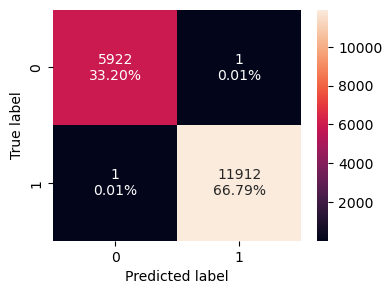

```python
confusion_matrix_sklearn(rf_estimator, X_train,y_train)
```

```python
rf_estimator_model_train = model_performance_classification_sklearn(rf_estimator, X_train,y_train)
rf_estimator_model_train
```

|  | Accuracy | Recall | Precision | F1 |
| --- | --- | --- | --- | --- |
| 0 | 0.999888 | 0.999916 | 0.999916 | 0.999916 |

#### Checking model performance on test set

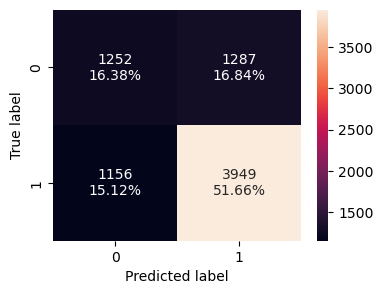

```python
confusion_matrix_sklearn(rf_estimator, X_test,y_test)
```

```python
rf_estimator_model_test =model_performance_classification_sklearn(rf_estimator, X_test,y_test)
rf_estimator_model_test
```

|  | Accuracy | Recall | Precision | F1 |
| --- | --- | --- | --- | --- |
| 0 | 0.680403 | 0.773555 | 0.754202 | 0.763756 |

Observation:

1. The random forest is overfitting the training data with all values as .99 for accuracy, recall, precision and f1.
2. The accuracy is lower at .68 for test data and reduced from previous model.
3. The recall is .77 , precision is .75 and f1 score is .763 for the test data.
4. The model performance similar to bagging classifier model.

#### Will tuning the hyperparameters improve this model performance?

### Hyperparameter Tuning - Random Forest

```python
# Choose the type of classifier.
rf_estimator_tuned = RandomForestClassifier(random_state=1, oob_score=True, bootstrap=True)

# Grid of parameters to choose from
parameters = {
        "max_depth": list(np.arange(5, 15, 5)),
    "max_features": ["sqrt", "log2"],
    "min_samples_split": [5, 7],
    "n_estimators": np.arange(15, 26, 5),
}

# Type of scoring used to compare parameter combinations
scorer = metrics.make_scorer(metrics.f1_score)

# Run the grid search
grid_obj = GridSearchCV(rf_estimator_tuned, parameters, scoring=scorer, cv=3,n_jobs=-1)
grid_obj = grid_obj.fit(X_train, y_train)

# Set the clf to the best combination of parameters
rf_estimator_tuned = grid_obj.best_estimator_

# Fit the best algorithm to the data.
rf_estimator_tuned.fit(X_train, y_train)
```

```
RandomForestClassifier(max_depth=10, min_samples_split=7, n_estimators=20,
                       oob_score=True, random_state=1)
```

#### Checking model performance on training set

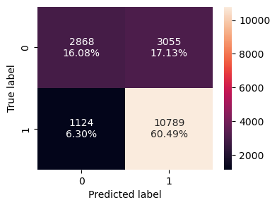

```python
confusion_matrix_sklearn(rf_estimator_tuned, X_train,y_train)
```

```python
rf_estimator_tuned_train = model_performance_classification_sklearn(rf_estimator_tuned, X_train,y_train)
rf_estimator_tuned_train
```

|  | Accuracy | Recall | Precision | F1 |
| --- | --- | --- | --- | --- |
| 0 | 0.765699 | 0.905649 | 0.779327 | 0.837753 |

#### Checking model performance on test set

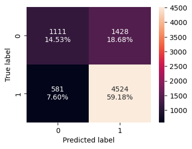

```python
confusion_matrix_sklearn(rf_estimator_tuned,  X_test,y_test)
```

```python
rf_estimator_tuned_test = model_performance_classification_sklearn(rf_estimator_tuned, X_test,y_test)
rf_estimator_tuned_test
```

|  | Accuracy | Recall | Precision | F1 |
| --- | --- | --- | --- | --- |
| 0 | 0.737179 | 0.88619 | 0.760081 | 0.818305 |

**Observation**:

1. The rf_estimator_tuned has reduced overfitting of the training data with .76 for accuracy, .90 for recall, .78 for precision and .83 for f1.
2. The accuracy has improved to .73 for test data, and therefore training and testing data performing similar on accuracy.
3. The recall is improved to .88 precision is at.76 and f1 score most important metric for this case is improved to .82.
4. The model performed quite close on training and testing data for all the metrics.
5. This is quite good model and definately improved from random forest classifier.

## Boosting - Model Building and Hyperparameter Tuning

### AdaBoost Classifier

```python
ab_classifier=AdaBoostClassifier(random_state=1)
ab_classifier.fit(X_train,y_train)
```

```
AdaBoostClassifier(random_state=1)
```

#### Checking model performance on training set

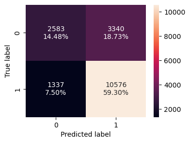

```python
confusion_matrix_sklearn(ab_classifier, X_train,y_train)
```

```python
ab_classifier_model_train = model_performance_classification_sklearn(ab_classifier,X_train,y_train)
ab_classifier_model_train
```

|  | Accuracy | Recall | Precision | F1 |
| --- | --- | --- | --- | --- |
| 0 | 0.737778 | 0.88777 | 0.759989 | 0.818924 |

#### Checking model performance on test set

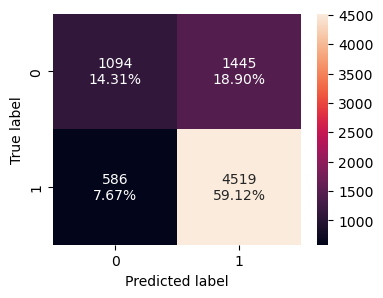

```python
confusion_matrix_sklearn(ab_classifier, X_test,y_test)
```

```python
ab_classifier_model_test = model_performance_classification_sklearn(ab_classifier,X_test,y_test)
ab_classifier_model_test
```

|  | Accuracy | Recall | Precision | F1 |
| --- | --- | --- | --- | --- |
| 0 | 0.734301 | 0.885211 | 0.757713 | 0.816515 |

**Observation**:

1. The ab_classifier_model is not at all overfitting the training data with .73 for accuracy, .88 for recall, .76 for precision and .82 for f1.
2. The accuracy has improved to .73 for test data and quite close to training data.
3. The recall is improved to .88 precision is at.75 and f1 score most important metric for this case is improved to .81.
4. This ab_classifier has improved the f1 score to .81 with similar performance on test and training data.
5. The performance of this model is quite close on all metrics for training and testing data.

#### Will tuning the hyperparameters improve the model performance?

### Hyperparameter Tuning - AdaBoost Classifier

```python
# Choose the type of classifier.
abc_tuned = AdaBoostClassifier(random_state=1)

# Grid of parameters to choose from
parameters = {
    #Let's try different max_depth for base_estimator
    "base_estimator":[DecisionTreeClassifier(max_depth=1),
                      DecisionTreeClassifier(max_depth=2)],
    "n_estimators": np.arange(80,101,10),
    "learning_rate":np.arange(0.1, 0.4, 0.1),
}

# Type of scoring used to compare parameter  combinations
acc_scorer = metrics.make_scorer(metrics.f1_score)

# Run the grid search
grid_obj = GridSearchCV(abc_tuned, parameters, scoring=acc_scorer,cv=3)
grid_obj = grid_obj.fit(X_train, y_train)

# Set the clf to the best combination of parameters
abc_tuned = grid_obj.best_estimator_

# Fit the best algorithm to the data.
abc_tuned.fit(X_train, y_train)
```

```
AdaBoostClassifier(base_estimator=DecisionTreeClassifier(max_depth=2),
                   learning_rate=0.1, n_estimators=90, random_state=1)
```

#### Checking model performance on training set

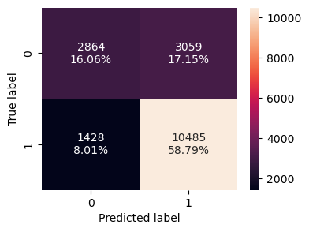

```python
confusion_matrix_sklearn(abc_tuned,X_train,y_train)
```

```python
abc_tuned_model_train=model_performance_classification_sklearn(abc_tuned,X_train,y_train)
abc_tuned_model_train
```

|  | Accuracy | Recall | Precision | F1 |
| --- | --- | --- | --- | --- |
| 0 | 0.74843 | 0.880131 | 0.774144 | 0.823742 |

#### Checking model performance on test set

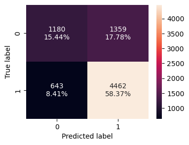

```python
confusion_matrix_sklearn(abc_tuned,X_test,y_test)
```

```python
abc_tuned_model_test=model_performance_classification_sklearn(abc_tuned,X_test,y_test)
abc_tuned_model_test
```

|  | Accuracy | Recall | Precision | F1 |
| --- | --- | --- | --- | --- |
| 0 | 0.738095 | 0.874045 | 0.766535 | 0.816767 |

**Observation**:

1. The abc_tuned_model is not at all overfitting the training data with .74 for accuracy, .88 for recall, .77 for precision and .82 for f1.
2. The accuracy has improved to .74 for test data and quite close to training data.
3. The recall is improved to .87 precision is at.76 and f1 score is improved to .81.
4. This ab_tuned_model has improved the f1 score to .81 with similar performance on test and training data.
5. The performance of this model is quite similar to ab_classifier.

### Gradient Boosting Classifier

```python
gb_classifier = GradientBoostingClassifier(random_state=1)
gb_classifier.fit(X_train,y_train)
```

```
GradientBoostingClassifier(random_state=1)
```

#### Checking model performance on training set

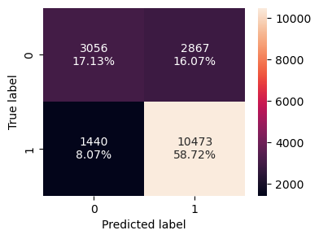

```python
#create a confusion matrix of the classifier's performance on the testing data
confusion_matrix_sklearn(gb_classifier, X_train,y_train)
```

```python
gbc_classifier_model_train = model_performance_classification_sklearn(gb_classifier,X_train,y_train)
gbc_classifier_model_train
```

|  | Accuracy | Recall | Precision | F1 |
| --- | --- | --- | --- | --- |
| 0 | 0.758522 | 0.879124 | 0.785082 | 0.829446 |

#### Checking model performance on test set

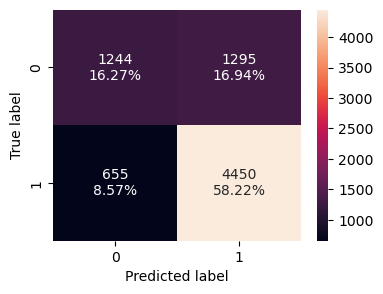

```python
#create a confusion matrix of the classifier's performance on the testing data
confusion_matrix_sklearn(gb_classifier, X_test,y_test)
```

```python
gbc_classifier_model_test = model_performance_classification_sklearn(gb_classifier,X_test,y_test)
gbc_classifier_model_test
```

|  | Accuracy | Recall | Precision | F1 |
| --- | --- | --- | --- | --- |
| 0 | 0.744898 | 0.871694 | 0.774587 | 0.820276 |

**Observation**:

1. The gbc_classifier_model is not overfitting the training data with .75 for accuracy, .88 for recall, .78 for precision and .83 for f1.
2. The accuracy is .74 for test data which quite close to training data.
3. The recall is improved to .87, precision is at.77 and f1 score is .82.
4. This gbc_classifier has improved the f1 score to .82 with similar performance on test and training data.
5. The performance of this model is quite good while performing similar on all metrics for training and testing data.

#### Will tuning the hyperparameters improve the model performance?

### Hyperparameter Tuning - Gradient Boosting Classifier

```python
# Choose the type of classifier.
gb_tuned = GradientBoostingClassifier(random_state=1)

# Grid of parameters to choose from
parameters = {
    "n_estimators": [200, 250],
    "subsample": [0.9, 1],
    "max_features": [0.8, 0.9],
    "learning_rate": np.arange(0.1, 0.21, 0.1),
}


# Type of scoring used to compare parameter combinations
scorer = metrics.make_scorer(metrics.f1_score)

# Run the grid search
grid_obj = GridSearchCV(gb_tuned, parameters, scoring=scorer,cv=3)
grid_obj = grid_obj.fit(X_train, y_train)

# Set the clf to the best combination of parameters
gb_tuned = grid_obj.best_estimator_

# Fit the best algorithm to the data.
gb_tuned.fit(X_train, y_train)
```

```
GradientBoostingClassifier(max_features=0.8, n_estimators=200, random_state=1,
                           subsample=1)
```

#### Checking model performance on training set

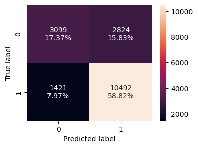

```python
confusion_matrix_sklearn(gb_tuned, X_train,y_train)
```

```python
gb_tuned_model_train=model_performance_classification_sklearn(gb_tuned,X_train,y_train)
gb_tuned_model_train
```

|  | Accuracy | Recall | Precision | F1 |
| --- | --- | --- | --- | --- |
| 0 | 0.761998 | 0.880719 | 0.787924 | 0.831741 |

#### Checking model performance on test set

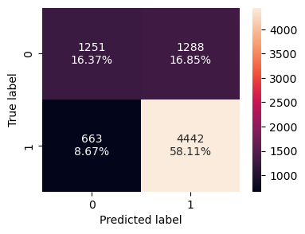

```python
confusion_matrix_sklearn(gb_tuned, X_test,y_test)
```

```python
gb_tuned_model_test = model_performance_classification_sklearn(gb_tuned,X_test,y_test)
gb_tuned_model_test
```

|  | Accuracy | Recall | Precision | F1 |
| --- | --- | --- | --- | --- |
| 0 | 0.744767 | 0.870127 | 0.775218 | 0.819935 |

**Observation**:

1. The gb_tuned_model is not overfitting the training data with .76 for accuracy, .88 for recall, .79 for precision and .83 for f1.
2. The accuracy is .74 for test data which quite close to training data.
3. The recall is improved to .87, precision is at.78 and f1 score is .82.
4. This model has f1 score of .82 with similar performance on test and training data.
5. The performance of gb_tuned_model is quite similar to gbc_classifier but changing hypertune parameters can lead to better performing model.

### XGBoost Classifier

```python
xgb = XGBClassifier(random_state=1,eval_metric='logloss')
xgb.fit(X_train,y_train)
```

```
XGBClassifier(base_score=None, booster=None, callbacks=None,
              colsample_bylevel=None, colsample_bynode=None,
              colsample_bytree=None, early_stopping_rounds=None,
              enable_categorical=False, eval_metric='logloss',
              feature_types=None, gamma=None, gpu_id=None, grow_policy=None,
              importance_type=None, interaction_constraints=None,
              learning_rate=None, max_bin=None, max_cat_threshold=None,
              max_cat_to_onehot=None, max_delta_step=None, max_depth=None,
              max_leaves=None, min_child_weight=None, missing=nan,
              monotone_constraints=None, n_estimators=100, n_jobs=None,
              num_parallel_tree=None, predictor=None, random_state=1, ...)
```

#### Checking model performance on training set

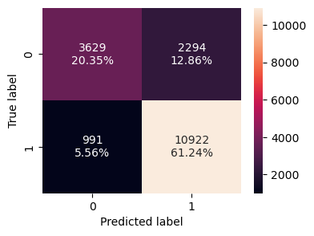

```python
confusion_matrix_sklearn(xgb, X_train,y_train)
```

```python
xgb_classifier_model_train = model_performance_classification_sklearn(xgb,X_train,y_train)
xgb_classifier_model_train
```

|  | Accuracy | Recall | Precision | F1 |
| --- | --- | --- | --- | --- |
| 0 | 0.815822 | 0.916814 | 0.826423 | 0.869275 |

#### Checking model performance on test set

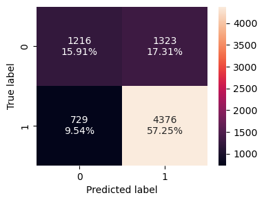

```python
confusion_matrix_sklearn(xgb, X_test,y_test)
```

```python
xgb_classifier_model_test = model_performance_classification_sklearn(xgb, X_test,y_test)
xgb_classifier_model_test
```

|  | Accuracy | Recall | Precision | F1 |
| --- | --- | --- | --- | --- |
| 0 | 0.731554 | 0.857199 | 0.767854 | 0.81007 |

**Observation**:

1. The xgb_classifier_model is slightly overfitting the training data with .81 for accuracy, .91 for recall, .83 for precision and .87 for f1.
2. The accuracy is reduced to .73 for test data and quite lower than training data.
3. The recall is reduced to .85, precision is at.76 and f1 score is .81.
4. The performance of this model is not quite good as compared to previous models.

#### Will tuning the hyperparameters improve the model performance?

### Hyperparameter Tuning - XGBoost Classifier

```python
# Choose the type of classifier.
xgb_tuned = XGBClassifier(random_state=1, eval_metric='logloss')

# Grid of parameters to choose from
parameters = {
    "n_estimators": [10,30,50],
    "scale_pos_weight":[1,2,5],
    "subsample":[0.7,0.9,1],
    "learning_rate":[0.05, 0.1,0.2],
    "colsample_bytree":[0.7,0.9,1],
    "colsample_bylevel":[0.5,0.7,1]
}

# Type of scoring used to compare parameter combinations
scorer = metrics.make_scorer(metrics.f1_score)

# Run the grid search
grid_obj = GridSearchCV(xgb_tuned, parameters,scoring=scorer,cv=3)
grid_obj = grid_obj.fit(X_train, y_train)

# Set the clf to the best combination of parameters
xgb_tuned = grid_obj.best_estimator_

# Fit the best algorithm to the data.
xgb_tuned.fit(X_train, y_train)
```

```
XGBClassifier(base_score=None, booster=None, callbacks=None,
              colsample_bylevel=0.7, colsample_bynode=None,
              colsample_bytree=0.7, early_stopping_rounds=None,
              enable_categorical=False, eval_metric='logloss',
              feature_types=None, gamma=None, gpu_id=None, grow_policy=None,
              importance_type=None, interaction_constraints=None,
              learning_rate=0.2, max_bin=None, max_cat_threshold=None,
              max_cat_to_onehot=None, max_delta_step=None, max_depth=None,
              max_leaves=None, min_child_weight=None, missing=nan,
              monotone_constraints=None, n_estimators=10, n_jobs=None,
              num_parallel_tree=None, predictor=None, random_state=1, ...)
```

#### Checking model performance on training set

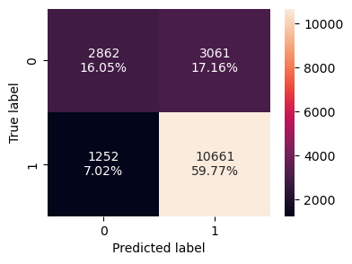

```python
confusion_matrix_sklearn(xgb_tuned,X_train, y_train)
```

```python
xgb_tuned_model_train = model_performance_classification_sklearn(xgb_tuned,X_train,y_train)
xgb_tuned_model_train
```

|  | Accuracy | Recall | Precision | F1 |
| --- | --- | --- | --- | --- |
| 0 | 0.758186 | 0.894905 | 0.776928 | 0.831753 |

#### Checking model performance on test set

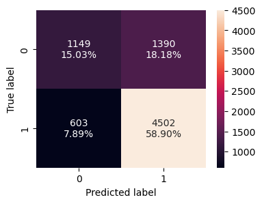

```python
confusion_matrix_sklearn(xgb_tuned,X_test,y_test)
```

```python
xgb_tuned_model_test= model_performance_classification_sklearn(xgb_tuned,X_test,y_test)
xgb_tuned_model_test
```

|  | Accuracy | Recall | Precision | F1 |
| --- | --- | --- | --- | --- |
| 0 | 0.739273 | 0.881881 | 0.764087 | 0.818769 |

**Observation**:

1. The xgb_tuned_model is not overfitting the training data with .76 for accuracy, .89 for recall, .77 for precision and .83 for f1.
2. The accuracy is .74 for test data and quite close to training data.
3. The recall is .88, precision is at.76 and f1 score is .82.
4. The performance of this model is quite good while performing similar on all metrics for training and testing data.

## Stacking Classifier

```python
estimators =  [("AdaBoost", ab_classifier),
    ("Gradient Boosting", gb_tuned),
    ("Decision tree", dtree_estimator),]

final_estimator = xgb_tuned

stacking_classifier= StackingClassifier(estimators=estimators,final_estimator=final_estimator)

stacking_classifier.fit(X_train,y_train)
```

```
StackingClassifier(estimators=[('AdaBoost', AdaBoostClassifier(random_state=1)),
                               ('Gradient Boosting',
                                GradientBoostingClassifier(max_features=0.8,
                                                           n_estimators=200,
                                                           random_state=1,
                                                           subsample=1)),
                               ('Decision tree',
                                DecisionTreeClassifier(max_depth=5,
                                                       max_leaf_nodes=4,
                                                       min_impurity_decrease=0.0001,
                                                       min_samples_leaf=3,
                                                       random_state=1))],
                   final_estimator=XGBClassifi...
                                                 gpu_id=None, grow_policy=None,
                                                 importance_type=None,
                                                 interaction_constraints=None,
                                                 learning_rate=0.2,
                                                 max_bin=None,
                                                 max_cat_threshold=None,
                                                 max_cat_to_onehot=None,
                                                 max_delta_step=None,
                                                 max_depth=None,
                                                 max_leaves=None,
                                                 min_child_weight=None,
                                                 missing=nan,
                                                 monotone_constraints=None,
                                                 n_estimators=10, n_jobs=None,
                                                 num_parallel_tree=None,
                                                 predictor=None, random_state=1, ...))
```

#### Checking model performance on training set

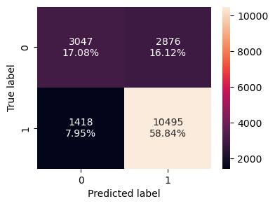

```python
confusion_matrix_sklearn(stacking_classifier,X_train,y_train)
```

```python
stacking_classifier_model_train = model_performance_classification_sklearn(stacking_classifier,X_train,y_train)
stacking_classifier_model_train
```

|  | Accuracy | Recall | Precision | F1 |
| --- | --- | --- | --- | --- |
| 0 | 0.759251 | 0.88097 | 0.784908 | 0.830169 |

#### Checking model performance on test set

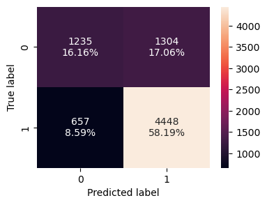

```python
confusion_matrix_sklearn(stacking_classifier,X_test,y_test)
```

```python
stacking_classifier_model_test=model_performance_classification_sklearn(stacking_classifier,X_test,y_test)
stacking_classifier_model_test
```

|  | Accuracy | Recall | Precision | F1 |
| --- | --- | --- | --- | --- |
| 0 | 0.743459 | 0.871303 | 0.773296 | 0.819379 |

**Observation**:

1. The stacking_classifier_model is not at all overfitting the training data with .76 for accuracy, .88 for recall, .78 for precision and .83 for f1.
2. The accuracy is .74 for test data which quite close to training data.
3. The recall is .87, precision is at.77 and f1 score is .82.
4. This stacking_classifier has improved the f1 score to .82 with similar performance on test and training data.
5. The performance of this model is quite good while performing similar on all metrics for training and testing data.

## Model Performance Comparison and Conclusions

### Comparing model performances of training set

```python
# training performance comparison

Models_train_comp_df = pd.concat(
    [
        decision_tree_perf_train.T,
        dtree_estimator_model_train.T,
        bagging_model_train.T,
        bagging_estimator_tuned_train.T,
        rf_estimator_model_train.T,
        rf_estimator_tuned_train.T,
        ab_classifier_model_train.T,
        abc_tuned_model_train.T,
        gbc_classifier_model_train.T,
        gb_tuned_model_train.T,
        xgb_classifier_model_train.T,
        xgb_tuned_model_train.T,
        stacking_classifier_model_train.T,
    ],
    axis=1,
)
Models_train_comp_df.columns = [
    "Decision Tree",
    "Tuned Decision Tree",
    "Bagging Classifier",
    "Tuned Bagging Classifier",
    "Random Forest",
    "Tuned Random Forest",
    "Adaboost Classifier",
    "Tuned Adaboost Classifier",
    "Gradient Boost Classifier",
    "Tuned Gradient Boost Classifier",
    "XGBoost Classifier",
    "XGBoost Classifier Tuned",
    "Stacking Classifier",
]
print("Training performance comparison:")
Models_train_comp_df
```

```
Training performance comparison:
```

|  | Decision Tree | Tuned Decision Tree | Bagging Classifier | Tuned Bagging Classifier | Random Forest | Tuned Random Forest | Adaboost Classifier | Tuned Adaboost Classifier | Gradient Boost Classifier | Tuned Gradient Boost Classifier | XGBoost Classifier | XGBoost Classifier Tuned | Stacking Classifier |
| --- | --- | --- | --- | --- | --- | --- | --- | --- | --- | --- | --- | --- | --- |
| Accuracy | 1.0 | 0.729816 | 0.979368 | 0.965071 | 0.999888 | 0.765699 | 0.737778 | 0.748430 | 0.758522 | 0.761998 | 0.815822 | 0.758186 | 0.759251 |
| Recall | 1.0 | 0.910602 | 0.980106 | 0.996978 | 0.999916 | 0.905649 | 0.887770 | 0.880131 | 0.879124 | 0.880719 | 0.916814 | 0.894905 | 0.880970 |
| Precision | 1.0 | 0.742912 | 0.988905 | 0.952904 | 0.999916 | 0.779327 | 0.759989 | 0.774144 | 0.785082 | 0.787924 | 0.826423 | 0.776928 | 0.784908 |
| F1 | 1.0 | 0.818254 | 0.984486 | 0.974443 | 0.999916 | 0.837753 | 0.818924 | 0.823742 | 0.829446 | 0.831741 | 0.869275 | 0.831753 | 0.830169 |

### Comparing model performances of test set

```python
# testing performance comparison

Models_test_comp_df = pd.concat(
    [
     decision_tree_perf_test.T,
     dtree_estimator_model_test.T,
     bagging_model_test.T,
     bagging_estimator_tuned_test.T,
     rf_estimator_model_test.T,
     rf_estimator_tuned_test.T,
     ab_classifier_model_test.T,
     abc_tuned_model_test.T,
     gbc_classifier_model_test.T,
     gb_tuned_model_test.T,
     xgb_classifier_model_test.T,
     xgb_tuned_model_test.T,
     stacking_classifier_model_test.T],

    axis=1,

)

Models_test_comp_df.columns = [

     "Decision Tree",
    "Tuned Decision Tree",
    "Bagging Classifier",
    "Tuned Bagging Classifier",
    "Random Forest",
    "Tuned Random Forest",
    "Adaboost Classifier",
    "Tuned Adaboost Classifier",
    "Gradient Boost Classifier",
    "Tuned Gradient Boost Classifier",
    "XGBoost Classifier",
    "XGBoost Classifier Tuned",
    "Stacking Classifier",
]
print("Testing performance comparison:\n")
Models_test_comp_df
```

```
Testing performance comparison:
```

|  | Decision Tree | Tuned Decision Tree | Bagging Classifier | Tuned Bagging Classifier | Random Forest | Tuned Random Forest | Adaboost Classifier | Tuned Adaboost Classifier | Gradient Boost Classifier | Tuned Gradient Boost Classifier | XGBoost Classifier | XGBoost Classifier Tuned | Stacking Classifier |
| --- | --- | --- | --- | --- | --- | --- | --- | --- | --- | --- | --- | --- | --- |
| Accuracy | 0.655939 | 0.655939 | 0.678571 | 0.721481 | 0.680403 | 0.737179 | 0.734301 | 0.738095 | 0.744898 | 0.744767 | 0.731554 | 0.739273 | 0.743459 |
| Recall | 0.748286 | 0.748286 | 0.752791 | 0.881881 | 0.773555 | 0.886190 | 0.885211 | 0.874045 | 0.871694 | 0.870127 | 0.857199 | 0.881881 | 0.871303 |
| Precision | 0.739593 | 0.739593 | 0.762803 | 0.746848 | 0.754202 | 0.760081 | 0.757713 | 0.766535 | 0.774587 | 0.775218 | 0.767854 | 0.764087 | 0.773296 |
| F1 | 0.743914 | 0.743914 | 0.757764 | 0.808767 | 0.763756 | 0.818305 | 0.816515 | 0.816767 | 0.820276 | 0.819935 | 0.810070 | 0.818769 | 0.819379 |

**Observations**:

1. All the boosting models have performed pretty well on testing and training data.
2. The hypertuned bagging classifier and random forest performed way better than respective untuned models.
3. Though most pf the boosting algorithams have performed quite well, I will use gbc_classifier_model as final model.
4. The gbc_classifer_model did not overfit the training data with accuracy of .75, recall - .88, precision - .78 and f1 - .83.
5. For testing data, accuracy - .745, recall - .87, precision - .77 and f1 - .82
6. The performance of this model on testing set is very close the training set on all the metrics.
7. This gbc_classifier has f1 score to .82 with similar performance on test and training data.
8. The performance of this model is quite good and is less cumputational extensive as compared tunes gradient boost or XGBoost.

### Important features of the final model

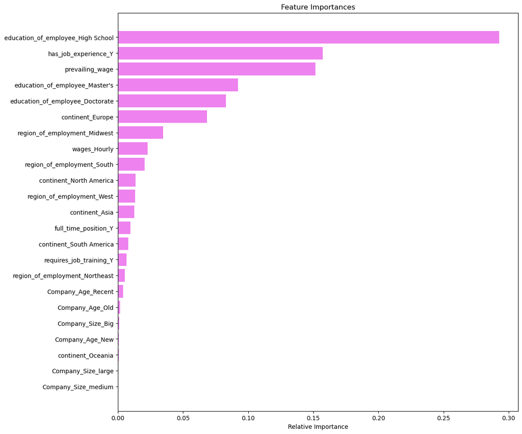

```python
#plot the important features of final model
feature_names = X_train.columns
importances = gb_classifier.feature_importances_
indices = np.argsort(importances)

plt.figure(figsize=(12, 12))
plt.title("Feature Importances")
plt.barh(range(len(indices)), importances[indices], color="violet", align="center")
plt.yticks(range(len(indices)), [feature_names[i] for i in indices])
plt.xlabel("Relative Importance")
plt.show()
```

**Observations**

1. Various education level are some of the important features in the model. The high school certification as highest education level seems to be most dominating feature of the model.
2. The 2nd important feature is job experience and chances of approval increases to 75% from 66% with applicant's prior job experience.
3. The prevailing wages specially hourly wages do have quite impact on certification rate of application.

## Actionable Insights and Recommendations

**Insights**

#### *Recommendations to Office of Foreign Labor Certification (OFLC)*:

The most critical components for pre-screening an applicant based on EDA and features of gb_classifier are :

- **Education level**: The applications can be pre-screened according to the highest degree of the applicants. With high chance of approval for Master's or Doctrate degree they can be prioritized more and applicants with high school diploma should be priortized least.
- **Job_experience**: The applicant without any previous job experience has 44% chances of denial incomparison to 25% for applicant with experience. Therefore applications can be pre-screened with job experience and priortized according to number of years of experience of the applicants.
- **Prevailing wages & unit_of_wages**: The lower prevailing wages have high chances of visa denial, especially below 35000. Lower hourly wages considerably increase the chances of denial of visa application. The higher annual prevailing wage of the job greatly improve the chances of application approval. After priortizing the application based on education level and job experience, application can sorted according to annual salaries for the applicant with similar education and experience levels.